# Daptomycin and streptogramins

Russell E. Lewis

2026-06-08

## Daptomycin and Streptogramins

**Russell E. Lewis, Pharm.D., FCCP**  
Associate Professor of Infectious Diseases

russelledward.lewis@unipd.it  
Slides and course materials: [www.idpadovaid.com](https://idpadova.com/)

## Learning Objectives

After this lecture, you should be able to:

1. Describe the mechanism of action of daptomycin
2. Understand daptomycin’s spectrum of activity and susceptibility testing
3. Explain mechanisms of daptomycin resistance
4. Apply appropriate dosing for different clinical scenarios
5. Recognize adverse effects and monitoring requirements
6. Identify clinical indications for daptomycin use

# Part 1: Daptomycin basics

## What is daptomycin?

- **Cyclic lipopeptide antibiotic** (1620.67 Da)
- Produced by *Streptomyces roseosporus*
- Discovered in the 1980s- Eli Lilly
- FDA approved: 2003 (US), 2006 (Europe)

Daptomycin has an interesting history - it was initially shelved due to muscle toxicity seen with twice-daily dosing. The “resurrection” came when researchers discovered that once-daily dosing dramatically reduced this toxicity while maintaining efficacy.

## Chemical structure

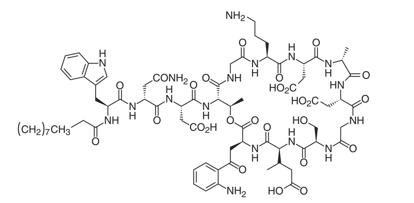

The structure shows the cyclic peptide core with a lipophilic tail (decanoic acid side chain). This amphipathic structure is critical for membrane insertion. The molecule contains 13 amino acids arranged in a cyclic structure.

## Mechanism of action

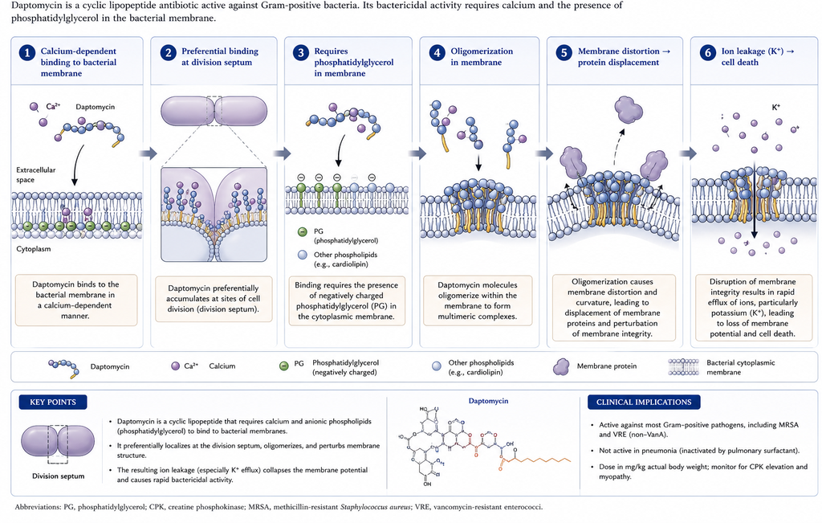

The calcium dependence is clinically important because susceptibility testing must use calcium-supplemented media. The binding at the division septum may explain why actively dividing cells are more susceptible. Recent work shows daptomycin also interacts with lipid-II, forming a tripartite complex that impedes peptidoglycan synthesis (Jung et al., 2004; Müller et al., 2016; Pogliano et al., 2012; Silverman et al., 2003).

## Key feature: Bactericidal without lysis

- Kills bacteria **without significant cell lysis**
- Results in **reduced inflammatory response**
- Less release of proinflammatory mediators
- Potential advantage in severe infections

This may be a clinical advantage compared to β-lactams and vancomycin, which cause cell lysis and release of inflammatory mediators. It has been hypothesized that this may translate to less inflammatory injury in infections like endocarditis (Silverman et al., 2003).

# Part 2: Antimicrobial spectrum

## Spectrum of activity

**Active against:**

- *Staphylococcus aureus* (MSSA, MRSA, VISA)
- Coagulase-negative staphylococci
- *Enterococcus faecalis* and *E. faecium* (including VRE)
- Streptococci
- Some gram-positive anaerobes

The spectrum closely overlaps glycopeptides but daptomycin often retains activity against organisms with decreased vancomycin susceptibility. **Activity against VRE is particularly important given limited treatment options.**

## Organisms with variable/No activity

**Variable activity:**

- *Actinomyces* spp. (MIC<sub>90</sub> 4-32 μg/mL)
- *Lactobacillus* spp.
- Some clostridial species

**No activity:**

- Gram-negative organisms
- **Pulmonary infections** (surfactant inactivation!)

Daptomycin is inactivated by pulmonary surfactant and should NEVER be used for pneumonia! This is a common board question and clinical error.

## Susceptibility testing challenges

**Warning**

**Calcium-supplemented Mueller-Hinton broth is REQUIRED** (50 μg/mL calcium concentration)

- Disk diffusion: **NOT recommended**
- Etest: Variable reproducibility
- Broth microdilution: Preferred method
- Significant interlaboratory variability exists

Susceptibility testing for daptomycin is notoriously challenging. Labs should be aware that results can vary significantly. When possible, broth microdilution should be used, especially for serious infections (Campeau et al., 2018; Humphries et al., 2011).

## Susceptibility breakpoints

| Organism | Susceptible | Intermediate | Resistant |
| --- | --- | --- | --- |
| Staphylococci | ≤1 μg/mL | - | >1 μg/mL |
| Streptococci | ≤1 μg/mL | - | >1 μg/mL |
| *E. faecalis* (FDA) | ≤4 μg/mL | - | - |
| *E. faecium* (CLSI 2019) | - | 2-4 μg/mL (SDD) | ≥8 μg/mL |

Note the important 2019 CLSI change for E. faecium - the susceptible category was eliminated! The SDD (susceptible dose-dependent) category requires high-dose daptomycin (8-12 mg/kg/day). EUCAST has not established breakpoints for daptomycin (Clinical and Laboratory Standards Institute, 2019).

# Part 3: Resistance Mechanisms

## Resistance is uncommon but…

- *In vitro*- resistance after serial passage is uncommon
- However “clinical resistance” emerges during therapy
- 6% of patients in pivotal bacteremia trial developed elevated MICs
- Risk factors:
  - Deep-seated/undrained infections
  - Prior vancomycin exposure
  - Inadequate dosing

While spontaneous resistance is rare, on-treatment emergence is a real concern, especially with undrained foci. This is why source control is essential and why combination therapy may be considered for complicated infections (Fowler et al., 2006; Sakoulas et al., 2006; Silverman et al., 2001).

## Phenotypic changes in resistant strains

- Enhanced membrane fluidity
- Increased positive surface charge
- Resistance to depolarization
- **Reduced phosphatidylglycerol content**
- Increased pigment production
- Decreased daptomycin binding

These changes all converge on reducing daptomycin’s ability to bind and insert into the membrane. The reduction in phosphatidylglycerol is particularly important as this is the primary membrane target (Mishra et al., 2012; Sakoulas et al., 2006).

## Genetic basis (*S. aureus*)

Key genes implicated:

1. *mprF* - LPG synthase/flippase → increased surface charge
2. *yycFG/walKR* - Cell envelope homeostasis
3. *vraSR* - Cell wall stress response
4. *dlt* operon - D-alanylation of teichoic acids
5. *pgsA/cls* - Phospholipid metabolism

Understanding these mechanisms helps explain the seesaw effect. Mutations that increase positive charge or decrease phosphatidylglycerol to resist daptomycin often make the organism more susceptible to β-lactams. This is the basis for combination therapy (Arias et al., 2011a; Howden et al., 2011; Peleg et al., 2012; Yang et al., 2010, 2009).

## The “Seesaw effect”

**Clinical Pearl**

Daptomycin resistance often leads to **increased β-lactam susceptibility**

- Basis for daptomycin + β-lactam combinations
- Demonstrated in vitro and in animal models
- Multiple β-lactams effective (oxacillin, ceftaroline, etc.)
- May prevent emergence of resistance

This is one of the most important practical concepts. When you see a patient failing daptomycin or with an isolate showing elevated MICs, consider adding a β-lactam. Even against MRSA, adding oxacillin or ceftaroline can be beneficial - not because of intrinsic activity, but because of the seesaw effect (Dhand et al., 2011; Mehta et al., 2012).

## Enterococcal resistance

- LiaFSR system is **central** to resistance
- Homologue of VraTSR in staphylococci
- Cell envelope stress response system
- Additional mutations in *gdpD*, *cls* genes
- Resistance can emerge WITHOUT prior exposure

Enterococcal resistance appears to be evolving somewhat independently of staphylococcal resistance. The LiaFSR system acts as a “sentinel” detecting antimicrobial peptides and orchestrating the stress response (Arias et al., 2011b; Khan et al., 2019; Tran et al., 2013).

# Part 4: Pharmacokinetics

## Key PK parameters

| Parameter | Value |
| --- | --- |
| Half-life | 7.3-9.6 hours |
| Protein binding | 90-93% |
| Volume of distribution | 92-117 mL/kg |
| Elimination | Renal (unchanged) |

The long half-life supports once-daily dosing. High protein binding means the drug distributes mainly to plasma and interstitial fluid. Primarily renal elimination necessitates dose adjustment in renal impairment (Benvenuto et al., 2006; Dvorchik et al., 2003).

## Peak concentrations by dose

| Dose (mg/kg) | Peak (μg/mL) | AUC (μg·hr/mL) |
| --- | --- | --- |
| 4 | ~55 | ~500 |
| 6 | ~86 | ~750 |
| 8 | ~116 | ~850 |
| 10 | ~130 | - |
| 12 | ~165 | - |

Note the linear pharmacokinetics up to 12 mg/kg. This supports the use of high-dose daptomycin in serious infections. PK/PD parameters correlating with efficacy are peak/MIC and AUC/MIC ratios (Benvenuto et al., 2006; Dvorchik et al., 2003; Louie et al., 2001).

## Tissue penetration

**Good penetration:**

- Skin/soft tissue (~68% of plasma)
- Cardiac vegetations (~50% of serum)

**Poor penetration:**

- CNS (~2-6%)
- Bone (variable)
- **Lungs (inactivated by surfactant!)**

DO NOT use for pneumonia! The good penetration into vegetations supports its use in endocarditis. Despite poor bone penetration, it has been used successfully in osteomyelitis, possibly due to concentration-dependent killing (Cottagnoud et al., 2004; Lee et al., 2008; Traunmüller et al., 2010; Wise et al., 2002).

# Part 5: Dosing

## FDA-EMA approved dosing

| Indication | Dose | Route |
| --- | --- | --- |
| ABSSSI | 4 mg/kg q24h | IV |
| Bacteremia/Right-sided endocarditis | 6 mg/kg q24h | IV |

**BUT…**

Experts recommend **8-12 mg/kg/day** for serious infections!

This is a critical point - FDA-approved doses are considered by many experts to be inadequate for serious infections. Data shows better outcomes with higher doses, especially for bacteremia with high mortality risk (Arbeit et al., 2004; Falcone et al., 2013; Fowler et al., 2006; Kullar et al., 2013).

## Renal dose adjustment

| CrCl | Dose Adjustment |
| --- | --- |
| ≥30 mL/min | No adjustment |
| <30 mL/min | Every 48 hours |
| Hemodialysis | After HD, q48h |
| CRRT | Variable - consider TDM |

For patients on CRRT, there’s no uniform recommendation. Drug monitoring may be helpful. Some suggest 8 mg/kg q48h for CVVHDF. Monitor CPK more frequently in renal impairment (Khadzhynov et al., 2011; Kielstein et al., 2014; US Food and Drug Administration, 2020).

## Special populations

- **Obesity**: No dose adjustment (use actual body weight)
- **Hepatic impairment**: No adjustment (Child-Pugh B)
- **Pediatrics**: FDA-approved, age-based dosing
- **Pregnancy**: Category B (insufficient human data)

(Ardura et al., 2007; Gonzalez et al., 2017; US Food and Drug Administration, 2020)

# Part 6: Adverse effects

## Muscle toxicity (Primary concern)

- **CPK elevation** (dose and duration dependent)
- Mechanism: Direct membrane toxicity to myofibers
- Risk factors:
  - C<sub>min</sub> ≥24.3 mg/L
  - Concurrent statin use
  - Renal impairment
  - Duration >7 days

Muscle toxicity was the reason daptomycin was initially shelved. Once-daily dosing dramatically reduced this (lower trough concentrations), but it remains the primary monitoring concern. The microscopic findings show degeneration-regeneration without lysis or fibrosis (Bhavnani et al., 2010; Dare et al., 2018; McConnell et al., 2017).

## CPK monitoring & management

**When to Stop Daptomycin**

- CPK >1000 units/L **WITH** symptoms
- CPK >2000 units/L (10× ULN) even without symptoms

**Monitor:**

- Baseline CPK before starting
- Weekly CPK (more often in renal impairment)
- Weekly in patients on statins

Symptoms typically appear after 7+ days of therapy and resolve within 3 days of stopping. Consider holding statins during daptomycin therapy if possible (Arbeit et al., 2004; Bhavnani et al., 2010; Fowler et al., 2006).

## Other adverse effects

| Effect | Frequency | Notes |
| --- | --- | --- |
| Eosinophilic pneumonia | Rare | After ~10 days; stop drug |
| Peripheral neuropathy | 9% vs 2% | Usually mild, reversible |
| GI symptoms | Common | Similar to comparators |
| Renal/hepatic | Rare | May be protective vs aminoglycosides |

Eosinophilic pneumonia is rare but potentially serious. Classic presentation: fever, dyspnea, pulmonary infiltrates, eosinophilia (peripheral or in BAL). High clinical suspicion needed - resolves with discontinuation, corticosteroids may help (Fowler et al., 2006; Silverman et al., 2007).

## Drug interactions

**Minimal CYP450 interactions** (not metabolized hepatically)

Monitor closely with:

- **Statins** - increased CPK risk
- PT/INR assays - may cause false elevation

The lack of CYP450 metabolism is advantageous as it reduces drug-drug interactions. However, the combination with statins is particularly important given the shared muscle toxicity concern (Dare et al., 2018; McConnell et al., 2017).

# Part 7: Clinical applications

## FDA/EMA-approved indications

1. **ABSSSI** (Acute Bacterial Skin & Skin Structure Infections)
   - *S. aureus* (MSSA, MRSA)
   - *Streptococcus pyogenes*
   - *E. faecalis* (vancomycin-susceptible)
2. *S. aureus* **bacteremia & right-sided endocarditis**

These are the official indications, but daptomycin is widely used off-label for other gram-positive infections, particularly VRE infections and left-sided endocarditis when other options fail (Arbeit et al., 2004; Fowler et al., 2006).

## Off-label uses

- **VRE infections** (bacteremia, endocarditis)
- Left-sided endocarditis (with other agents)
- Osteomyelitis
- Prosthetic joint infections
- CNS infections (limited data)

For VRE, daptomycin is often a first-line choice given limited alternatives. For left-sided endocarditis, combination therapy is typically used. High doses (8-12 mg/kg) are recommended for serious infections.

## When to consider daptomycin

- MRSA with vancomycin MIC ≥1.5-2 μg/mL
- Vancomycin failure or intolerance
- VRE infections
- Concern for nephrotoxicity
- Desire for once-daily dosing

The threshold for switching from vancomycin based on MIC is debated, but many clinicians become concerned with MICs approaching or at 2 μg/mL (the current breakpoint). Retrospective data suggest better outcomes with daptomycin in these scenarios (Kullar et al., 2011; Moore et al., 2012; Murray et al., 2013).

## When NOT to use daptomycin

**Important**

**NEVER use for pneumonia!**

Also avoid:

- Known daptomycin-resistant organism
- Prior daptomycin failure
- Active rhabdomyolysis
- Untreated source of infection

The pneumonia contraindication cannot be overemphasized. This is true even for MRSA pneumonia where vancomycin MIC is elevated - use linezolid or other alternatives instead.

# Part 8: Combination therapy strategies

## Rationale for Combinations

1. Prevent emergence of resistance
2. Exploit the seesaw effect
3. Enhance bactericidal activity
4. Treat complicated/deep-seated infections

Combination therapy is increasingly used, especially for endocarditis and persistent bacteremia. The evidence base is largely from in vitro, animal, and retrospective human studies (Dhand et al., 2011; Mehta et al., 2012; Sakoulas et al., 2014a).

## Daptomycin + β-lactam

**Best supported combination:**

- Oxacillin/nafcillin
- Ceftaroline (excellent data)
- Ceftriaxone, cefotaxime
- Ertapenem
- Even ampicillin-sulbactam

Ceftaroline is particularly interesting because it has intrinsic anti-MRSA activity AND provides the seesaw synergy. Multiple case reports show success with daptomycin + ceftaroline for otherwise refractory MRSA infections (Barber et al., 2015; Dhand et al., 2011; Mehta et al., 2012; Sakoulas et al., 2014b).

## Other combinations

| Partner | Evidence | Comment |
| --- | --- | --- |
| Gentamicin | In vitro synergy | Nephrotoxicity concern |
| Rifampin | Variable | May be antagonistic |
| Fosfomycin | Emerging data | Limited availability |
| Trimethoprim-sulfamethoxazole | Case reports | For MRSA |

Be cautious with rifampin - some studies show antagonism. Gentamicin adds synergy but nephrotoxicity risk. The β-lactam combination is generally preferred based on current evidence (Credito et al., 2007; Rose et al., 2012).

## Case example: Persistent MRSA bacteremia

**Scenario:** Day 7 of vancomycin, blood cultures still positive

**Approach:**

1. Switch to high-dose daptomycin (8-10 mg/kg)
2. Add β-lactam (ceftaroline or oxacillin)
3. Ensure source control 4. Monitor CPK closely

This is a common clinical scenario. Key points: ensure adequate daptomycin dosing, add β-lactam for synergy and to prevent resistance, and don’t forget about source control - undrained foci are the #1 reason for persistence (Dhand et al., 2011; Fowler et al., 2006; Kullar et al., 2013).

# Part 9: Quinupristin-Dalfopristin (Brief overview)

## Quinupristin-dalfopristin basics

- Streptogramin B (30%) + Streptogramin A (70%)
- Trade name: Synercid
- Target: 50S ribosomal subunit
- **Limited clinical use** **due to:**
  - Central line requirement
  - Arthralgias/myalgias
  - Infusion site reactions
  - Limited availability

Q-D is included for completeness but is rarely used. It was approved for VRE but that approval was withdrawn. Main remaining use is selected VRE infections in combination with other agents.

## Quinupristin-dalfopristin spectrum & dosing

**Active against:**

- Most gram-positives EXCEPT *E. faecalis*
- Some gram-negatives (*H. influenzae*, *M. catarrhalis*)

**Dosing:** 7.5 mg/kg IV q12h (1-hour infusion)

**No renal adjustment needed**

The intrinsic resistance of E. faecalis is important - limits utility for VRE infections. Hepatic dose reduction may be considered. CYP3A4 inhibitor - watch for drug interactions!

## Quinupristin-dalfopristin: Why it’s rarely used

- Arthralgias/myalgias (up to 50%)
- Severe infusion site reactions
- Requires central venous access
- CYP3A4 drug interactions
- Limited availability -Italian marketing authorization revoked
- Better alternatives exist (linezolid, daptomycin)

In practice, daptomycin and linezolid have largely replaced Q-D. It may still have a role in combination with daptomycin for refractory VRE infections.

# Summary & Key Takeaways

## Daptomycin key points

1. **Calcium-dependent** cyclic lipopeptide
2. Bactericidal without cell lysis
3. Spectrum similar to vancomycin but active against VISA/VRE
4. **Never use for pneumonia** (surfactant inactivation)
5. Monitor **CPK** - stop if elevated with symptoms
6. Use **high doses** (8-12 mg/kg) for serious infections

## Clinical pearls

**Tip**

- Consider daptomycin when vancomycin MIC ≥1.5-2 μg/mL
- Add β-lactam for persistent bacteremia
- The “seesaw effect” makes β-lactam combinations logical
- Renal dosing: extend interval, don’t reduce dose
- Check CPK baseline and weekly; more often with renal impairment or statins

## Questions to consider

1. Why can’t daptomycin be used for pneumonia?
2. What is the seesaw effect and how is it clinically useful?
3. When should you suspect daptomycin resistance?
4. What CPK level should prompt discontinuation?
5. Why is high-dose daptomycin preferred for serious infections?

## References

Arbeit RD, Maki D, Tally FP, et al. The safety and efficacy of daptomycin for the treatment of complicated skin and skin-structure infections. Clinical Infectious Diseases 2004;38:1673–81.

Ardura MI, Mejias A, Katz KS, et al. Daptomycin therapy for invasive gram-positive bacterial infections in children. Pediatric Infectious Disease Journal 2007;26:1128–32.

Arias CA, Panesso D, McGrath DM, Qin X, et al. Genetic basis for in vivo daptomycin resistance in enterococci. New England Journal of Medicine 2011a;365:892–900.

Arias CA, Panesso D, McGrath DM, Qin X, Mojica MF, et al. Genetic basis for in vivo daptomycin resistance in enterococci. New England Journal of Medicine 2011b;365:892–900.

Barber KE, Werth BJ, Ireland CE, Rybak MJ. Potent synergy of ceftaroline plus daptomycin against methicillin-resistant staphylococcus aureus with reduced vancomycin susceptibility. Antimicrobial Agents and Chemotherapy 2015;59:4329–32.

Benvenuto M, Benziger DP, Yankelev S, Vigliani G. Pharmacokinetics and tolerability of daptomycin at doses up to 12 milligrams per kilogram of body weight once daily in healthy volunteers. Antimicrobial Agents and Chemotherapy 2006;50:3245–9.

Bhavnani SM, Rubino CM, Ambrose PG, Drusano GL. Daptomycin exposure and the probability of elevations in the creatine phosphokinase level. Clinical Infectious Diseases 2010;50:1568–74.

Campeau SA, Schuetz AN, Humphries RM. Variability of daptomycin MIC values for staphylococcus aureus and enterococcus species in reference and clinical microbiology laboratories. Journal of Clinical Microbiology 2018;56:e01598–17.

Clinical and Laboratory Standards Institute. Performance standards for antimicrobial susceptibility testing. 29th ed. CLSI; 2019.

Cottagnoud P, Pfister M, Acosta F, et al. Daptomycin is highly efficacious against penicillin-resistant and penicillin- and quinolone-resistant pneumococci in experimental meningitis. Antimicrobial Agents and Chemotherapy 2004;48:3928–33.

Credito K, Lin G, Appelbaum PC. Activity of daptomycin alone and in combination with rifampin and gentamicin against staphylococcus aureus assessed by time-kill methodology. Antimicrobial Agents and Chemotherapy 2007;51:1504–7.

Dare RK, Tewell C, Harris B, et al. Effect of statin coadministration on the risk of daptomycin-associated myopathy. Clinical Infectious Diseases 2018;67:1356–63.

Dhand A, Bayer AS, Pogliano J, Yang SJ, et al. Use of antistaphylococcal β-lactams to increase daptomycin activity in eradicating persistent bacteremia due to methicillin-resistant staphylococcus aureus. Clinical Infectious Diseases 2011;53:158–63.

Dvorchik BH, Brazier D, DeBruin MF, Arbeit RD. Daptomycin pharmacokinetics and safety following administration of escalating doses once daily to healthy subjects. Antimicrobial Agents and Chemotherapy 2003;47:1318–23.

Falcone M, Russo A, Cassetta MI, et al. Variability of pharmacokinetic parameters in patients receiving different dosages of daptomycin: Is therapeutic drug monitoring necessary? Journal of Infection and Chemotherapy 2013;19:732–9.

Fowler VG, Boucher HW, Corey GR, Abrutyn E, Karchmer AW, et al. Daptomycin versus standard therapy for bacteremia and endocarditis caused by staphylococcus aureus. New England Journal of Medicine 2006;355:653–65.

Gonzalez D, Bradley JS, Blumer J, et al. Daptomycin in children: Report of a phase 3 efficacy and safety trial for skin and skin structure infections. Pediatric Infectious Disease Journal 2017;36:749–56.

Howden BP, McEvoy CR, Allen DL, Chua K, et al. Evolution of multidrug resistance during staphylococcus aureus infection involves mutation of the essential two component regulator WalKR. PLoS Pathogens 2011;7:e1002359.

Humphries RM, Kelesidis T, Tewhey R, Rose WE, Schork N, et al. Genotypic and phenotypic evaluation of the evolution of high-level daptomycin nonsusceptibility in vancomycin-resistant enterococcus faecium. Antimicrobial Agents and Chemotherapy 2011;56:6051–5.

Jung D, Rozek A, Okon M, Hancock RE. Structural transitions as determinants of the action of the calcium-dependent antibiotic daptomycin. Chemistry and Biology 2004;11:949–57.

Khadzhynov D, Slowinski T, Lieker I, et al. Plasma pharmacokinetics of daptomycin in critically ill patients with renal failure and undergoing CVVHD. International Journal of Clinical Pharmacology and Therapeutics 2011;49:656–65.

Khan A, Tran TT, Dinh AQ, et al. Antimicrobial sensing coupled with cell membrane remodeling mediates antibiotic resistance and virulence in enterococcus faecalis. Proceedings of the National Academy of Sciences 2019;116:26925–32.

Kielstein JT, Eugbers C, Bode-Böger SM, et al. Dosing of daptomycin in intensive care unit patients with acute kidney injury undergoing extended dialysis. Intensive Care Medicine 2014;40:1735–42.

Kullar R, Casapao AM, Davis SL, et al. A multicentre evaluation of the effectiveness and safety of high-dose daptomycin for the treatment of infective endocarditis. Journal of Antimicrobial Chemotherapy 2013;68:2921–6.

Kullar R, Davis SL, Taylor TN, et al. Effects of targeting higher vancomycin trough levels on clinical outcomes and costs in a matched patient cohort. Pharmacotherapy 2011;32:195–201.

Lee DH, Palermo B, Chowdhury M. Successful treatment of methicillin-resistant staphylococcus aureus meningitis with daptomycin. Clinical Infectious Diseases 2008;47:588–90.

Louie A, Kaw P, Liu W, Jumbe N, et al. Pharmacodynamics of daptomycin in a murine thigh model of staphylococcus aureus infection. Antimicrobial Agents and Chemotherapy 2001;45:845–51.

McConnell HL, Perris EE, Lowry C, et al. Risk factors for myopathy with concomitant statin and daptomycin use. Open Forum Infectious Diseases 2017;4:S316.

Mehta S, Singh C, Plata KB, Chanda PK, et al. Β-lactams increase the antibacterial activity of daptomycin against clinical methicillin-resistant staphylococcus aureus strains and prevent selection of daptomycin-resistant derivatives. Antimicrobial Agents and Chemotherapy 2012;56:6192–200.

Mishra NN, Bayer AS, Weidenmaier C, Grber T, et al. Phenotypic and genotypic characterization of daptomycin-resistant methicillin-resistant staphylococcus aureus strains. Antimicrobial Agents and Chemotherapy 2012;56:4324–32.

Moore CL, Osaki-Kiyan P, Haque NZ, et al. Daptomycin versus vancomycin for bloodstream infections due to methicillin-resistant staphylococcus aureus with a high vancomycin minimum inhibitory concentration. Clinical Infectious Diseases 2012;54:51–8.

Müller A, Wenzel M, Strahl H, Zervosen A, Campagne S, et al. Daptomycin inhibits cell envelope synthesis by interfering with fluid membrane microdomains. Proceedings of the National Academy of Sciences 2016;113:E7077–86.

Murray KP, Zhao JJ, Davis SL, et al. Early use of daptomycin versus vancomycin for methicillin-resistant staphylococcus aureus bacteremia with vancomycin minimum inhibitory concentration >1 mg/l: A matched cohort study. Clinical Infectious Diseases 2013;56:1562–9.

Peleg AY, Miyakis S, Ward DV, Earl AM, et al. Whole genome characterization of the mechanisms of daptomycin resistance in clinical and laboratory derived isolates of staphylococcus aureus. PLoS ONE 2012;7:e28316.

Pogliano J, Pogliano N, Silverman JA. Daptomycin-mediated reorganization of membrane architecture causes mislocalization of essential cell division proteins. Journal of Bacteriology 2012;194:4494–504.

Rose WE, Berti AD, Hatch JB, Rybak MJ. Relationship of in vitro synergy and treatment outcome with daptomycin plus rifampin in patients with invasive methicillin-resistant staphylococcus aureus infections. Antimicrobial Agents and Chemotherapy 2012;57:3450–2.

Sakoulas G, Alder J, Thauvin-Eliopoulos C, Moellering RC, Eliopoulos GM. Induction of daptomycin heterogeneous susceptibility in staphylococcus aureus by exposure to vancomycin. Antimicrobial Agents and Chemotherapy 2006;50:1581–5.

Sakoulas G, Bayer AS, Pogliano J, Tsuji BT, et al. Ampicillin enhances daptomycin- and cationic host defense peptide-mediated killing of ampicillin- and vancomycin-resistant enterococcus faecium. Antimicrobial Agents and Chemotherapy 2014a;56:838–44.

Sakoulas G, Okumura CY, Thiber W, et al. Nafcillin enhances innate immune-mediated killing of methicillin-resistant staphylococcus aureus. Journal of Molecular Medicine 2014b;92:139–49.

Silverman JA, Mortin LI, VanPraagh AD, et al. Inhibition of daptomycin by pulmonary surfactant: In vitro modeling and clinical impact. Journal of Infectious Diseases 2007;191:2149–52.

Silverman JA, Oliver N, Andrew T, Li T. Resistance studies with daptomycin. Antimicrobial Agents and Chemotherapy 2001;45:1799–802.

Silverman JA, Perlmutter NG, Shapiro HM. Correlation of daptomycin bactericidal activity and membrane depolarization in staphylococcus aureus. Antimicrobial Agents and Chemotherapy 2003;47:2538–44.

Tran TT, Panesso D, Mishra NN, Mileykovskaya E, et al. Daptomycin-resistant enterococcus faecalis diverts the antibiotic molecule from the division septum and remodels cell membrane phospholipids. MBio 2013;4:e00281–13.

Traunmüller F, Schintler MV, Metzler J, et al. Soft tissue and bone penetration abilities of daptomycin in diabetic patients with bacterial foot infections. Journal of Antimicrobial Chemotherapy 2010;65:1252–7.

US Food and Drug Administration. Cubicin (daptomycin for injection) prescribing information. FDA; 2020.

Wise R, Gee T, Andrews JM, Dvorchik B, Marshall G. Pharmacokinetics and inflammatory fluid penetration of intravenous daptomycin in volunteers. Antimicrobial Agents and Chemotherapy 2002;46:31–3.

Yang SJ, Kreiswirth BN, Sakoulas G, Yeaman MR, Bayer AS. Enhanced expression of dltABCD is associated with the development of daptomycin nonsusceptibility in a clinical endocarditis isolate of staphylococcus aureus. Journal of Infectious Diseases 2009;200:1916–20.

Yang SJ, Nast CC, Mishra NN, Yeaman MR, et al. Cell wall thickening is not a universal accompaniment of the daptomycin nonsusceptibility phenotype in staphylococcus aureus. Antimicrobial Agents and Chemotherapy 2010;54:3422–6.